# Time Series Model for [Project Name] Using Python Version 1

### 2.d) Box and Whisker Plots of the Time Series Data

We can group or aggregate the data and get a better idea of the spread of observations. Some observations from reviewing the plot can include:

- Whether the median values for each grouping shows any significant trend
- Whether the spread, or middle 50% of the data, shows any significant variability
- Whether there are outliers in some grouping

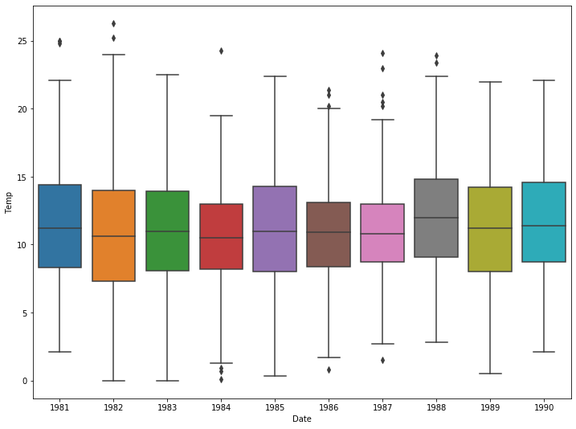

```python
# boxplots of time series
fig, ax = plt.subplots(figsize=(12,9))
squeezed = time_series.squeeze()
sns.boxplot(squeezed.index.year, squeezed, ax=ax)
plt.show()
```

```python
if (notifyStatus): email_notify("Data Inspection and Exploration completed! "+datetime.now().strftime('%a %B %d, %Y %I:%M:%S %p'))
```

## Section 3. Data Transformation and Stationarity Tests

```python
if (notifyStatus): email_notify("Data Cleaning and Pre-Processing has begun! "+datetime.now().strftime('%a %B %d, %Y %I:%M:%S %p'))
```

### Section 3.a) Data Transformation

```python
# Resampling the time series into monthly average for the ease of modeling
original_series = time_series
resample = original_series.resample('M')
time_series = resample.mean()
time_series.head(10)
```

| Date | Temp |
| --- | --- |
| 1981-01-31 | 17.712903 |
| 1981-02-28 | 17.678571 |
| 1981-03-31 | 13.500000 |
| 1981-04-30 | 12.356667 |
| 1981-05-31 | 9.490323 |
| 1981-06-30 | 7.306667 |
| 1981-07-31 | 7.577419 |
| 1981-08-31 | 7.238710 |
| 1981-09-30 | 10.143333 |
| 1981-10-31 | 10.087097 |

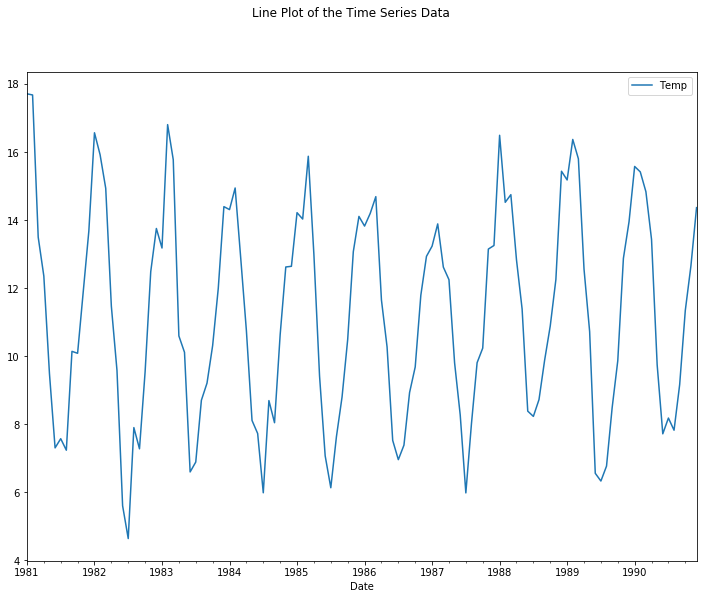

```python
# Line plots of the transformed time series
fig, ax = plt.subplots(figsize=(12,9))
fig.suptitle('Line Plot of the Time Series Data')
time_series.plot(ax=ax)
plt.show()
```

### Section 3.b) Test for Stationarity

```python
# Check if stationary
result = adfuller(time_series[target_col])
print('ADF Statistic: %f' % result[0])
print('p-value: %f' % result[1])
print('Critical Test Statistics Values:')
for key, value in result[4].items():
    print('\t%s: %.3f' % (key, value))
```

```
ADF Statistic: -1.892313
p-value: 0.335686
Critical Test Statistics Values:
	1%: -3.494
	5%: -2.889
	10%: -2.582
```

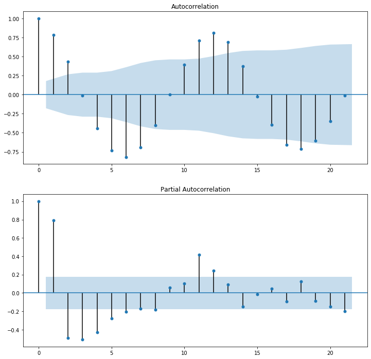

```python
# ACF and PACF plots of the time series data
fig, (ax1, ax2) = plt.subplots(2, 1, figsize=(12,12))
plot_acf(time_series, ax=ax1)
plot_pacf(time_series, ax=ax2)
plt.show()
```

### 3.c) Test for Stationarity of Non-Seasonal Time Series Data

Occasionally a time series may look non-stationary on the first look. We can make it stationary by differencing the series and using a statistical test to confirm that the differenced result is stationary. Rejecting the null hypothesis means that the process has no unit root, and in turn that the time series is stationary or does not have time-dependent structure.

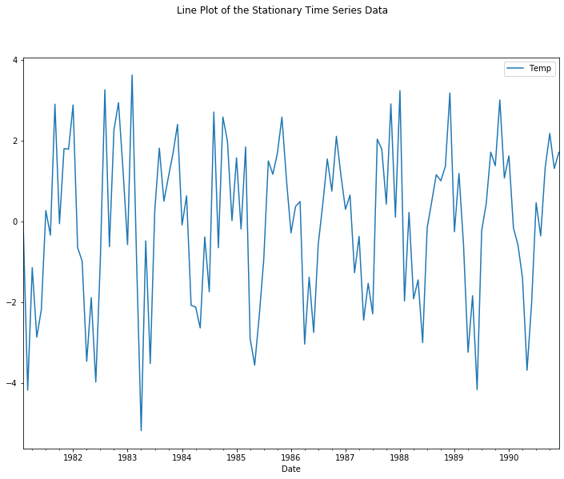

```python
# Create a differenced series
stationary_ns = time_series.diff().dropna()

# Plot differenced data
fig, ax = plt.subplots(figsize=(12,9))
fig.suptitle('Line Plot of the Stationary Time Series Data')
stationary_ns.plot(ax=ax)
plt.show()
```

```python
# Check for stationarity
result = adfuller(stationary_ns[target_col])
print('ADF Statistic: %f' % result[0])
print('p-value: %f' % result[1])
print('Critical Test Statistics Values:')
for key, value in result[4].items():
    print('\t%s: %.3f' % (key, value))
```

```
ADF Statistic: -4.629576
p-value: 0.000114
Critical Test Statistics Values:
	1%: -3.494
	5%: -2.889
	10%: -2.582
```

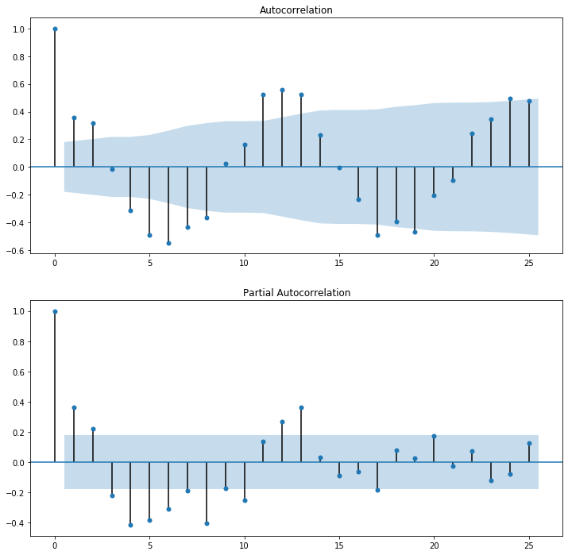

```python
# ACF and PACF plots of the stationary time series
lags = 25
fig, (ax1, ax2) = plt.subplots(2, 1, figsize=(12,12))
plot_acf(stationary_ns, lags=lags, ax=ax1)
plot_pacf(stationary_ns, lags=lags, ax=ax2)
plt.show()
```

### 3.d) Seasonal Decomposition for Seasonal Time Series Data

```python
# Set the initial seasonal frequency parameter
seasonal_freq = 12
```

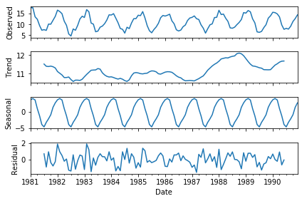

```python
# Perform seasonal decomposition to observe the seasonal frequency
decomp_results = seasonal_decompose(time_series, freq=seasonal_freq)
decomp_results.plot()
plt.show()
```

```python
# Detrending the time series
N = seasonal_freq
detrend = time_series - time_series.rolling(N).mean()
detrend = detrend.dropna()
```

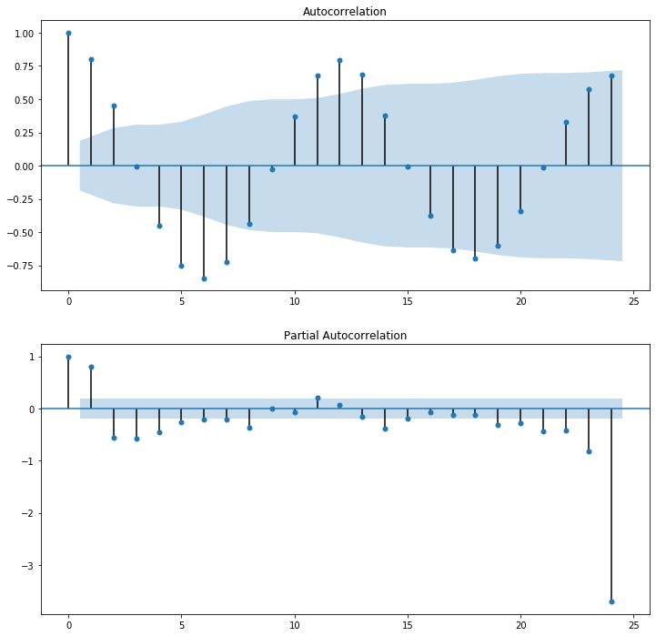

```python
# ACF and PACF plots of the time series data
lag = seasonal_freq * 2
fig, (ax1, ax2) = plt.subplots(2, 1, figsize=(12,12))
plot_acf(detrend, lags=lag, ax=ax1)
plot_pacf(detrend, lags=lag, ax=ax2)
plt.show()
```

### 3.e) Test for Stationarity of Seasonal Time Series Data

Occasionally a time series may look non-stationary on the first look. We can make it stationary by differencing the series and using a statistical test to confirm that the differenced result is stationary. Rejecting the null hypothesis means that the process has no unit root, and in turn that the time series is stationary or does not have time-dependent structure.

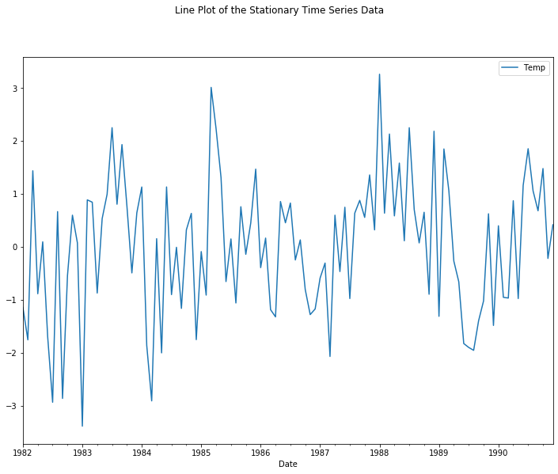

```python
# Create a differenced series
stationary_ss = time_series.diff(seasonal_freq).dropna()

# Plot differenced data
fig, ax = plt.subplots(figsize=(12,9))
fig.suptitle('Line Plot of the Stationary Time Series Data')
stationary_ss.plot(ax=ax)
plt.show()
```

```python
# Check for stationarity
result = adfuller(stationary_ss[target_col])
print('ADF Statistic: %f' % result[0])
print('p-value: %f' % result[1])
print('Critical Test Statistics Values:')
for key, value in result[4].items():
    print('\t%s: %.3f' % (key, value))
```

```
ADF Statistic: -4.755860
p-value: 0.000066
Critical Test Statistics Values:
	1%: -3.500
	5%: -2.892
	10%: -2.583
```

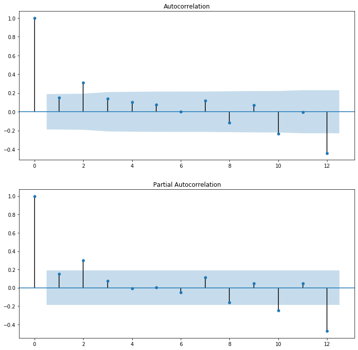

```python
# ACF and PACF plots of the stationary time series
lags = seasonal_freq
fig, (ax1, ax2) = plt.subplots(2, 1, figsize=(12,12))
plot_acf(stationary_ss, lags=lags, ax=ax1)
plot_pacf(stationary_ss, lags=lags, ax=ax2)
plt.show()
```

```python
if (notifyStatus): email_notify("Data Cleaning and Pre-Processing completed! "+datetime.now().strftime('%a %B %d, %Y %I:%M:%S %p'))
```

## Section 4. Fit and Evaluate Models

In this section, we will develop Autoregressive Integrated Moving Average or ARIMA models for the problem. We will first establish a persistent model. Next we will use a grid search approach to look for an optimal ARIMA model. This will be followed by a third step of investigating the residual errors of the chosen model.

- Establish the Persistent Model
- Automatically Configure the ARIMA
- Review Residual Errors

```python
if (notifyStatus): email_notify("Model Fitting and Evaluation has begun! "+datetime.now().strftime('%a %B %d, %Y %I:%M:%S %p'))
```

### 4.a) Establish the Persistent Model

The first step before getting bogged down in data analysis and modeling is to establish a baseline of performance. This will provide both a template for evaluating models using the proposed test harness and a performance measure by which all more elaborate predictive models can be compared.

The baseline prediction for time series forecasting is called the naive forecast, or persistence. This is where the observation from the previous time step is used as the prediction for the observation at the next time step.

#### 4.a.iii) Establish the Persistent Model as Baseline

```python
# Prepare and evaluate a persistence model
X = time_series.values
X = X.astype('float32')
train_pct = 0.80
train_size = int(len(X) * train_pct)
test_size = len(X) - train_size
train_ts, test_ts = X[0:train_size], X[train_size:]

# walk-forward validation
history = [x for x in train_ts]
predictions = list()
for i in range(len(test_ts)):
    yhat = history[-1]
    predictions.append(yhat)
    obs = test_ts[i]
    history.append(obs)
    print('>Predicted=%.3f, Expected=%3.f' % (yhat, obs))

# Calculate performance
rmse = math.sqrt(mean_squared_error(test_ts, predictions))
print('RMSE for the persistent model is: %.3f' % rmse)
```

```
>Predicted=15.437, Expected= 15
>Predicted=15.181, Expected= 16
>Predicted=16.371, Expected= 16
>Predicted=15.803, Expected= 13
>Predicted=12.563, Expected= 11
>Predicted=10.726, Expected=  7
>Predicted=6.560, Expected=  6
>Predicted=6.332, Expected=  7
>Predicted=6.771, Expected=  8
>Predicted=8.487, Expected= 10
>Predicted=9.868, Expected= 13
>Predicted=12.877, Expected= 14
>Predicted=13.952, Expected= 16
>Predicted=15.577, Expected= 15
>Predicted=15.418, Expected= 15
>Predicted=14.835, Expected= 13
>Predicted=13.433, Expected= 10
>Predicted=9.748, Expected=  8
>Predicted=7.720, Expected=  8
>Predicted=8.184, Expected=  8
>Predicted=7.826, Expected=  9
>Predicted=9.167, Expected= 11
>Predicted=11.345, Expected= 13
>Predicted=12.657, Expected= 14
RMSE for the persistent model is: 1.855
```

### 4.b) Grid Search of ARIMA Hyperparameters

We want to find a model that can do better than the persistence model on this dataset. To confirm this analysis, we can grid search a suite of ARIMA hyperparameters.

In this section, we will search values of p, d, and q for combinations (skipping those that fail to converge), and find the combination that results in the best performance. We will use a grid search to explore all combinations in a subset of integer values.

```python
if (notifyStatus): email_notify("ARIMA Hyperparameters Search has begun! "+datetime.now().strftime('%a %B %d, %Y %I:%M:%S %p'))
```

```python
# Testing the time series data for suggestions on the differencing term
print('The suggested non-seasonal differencing term is:', pm.arima.ndiffs(time_series))
if (seasonal_freq != 0): print('The suggested seasonal differencing term is:', pm.arima.nsdiffs(time_series, m = seasonal_freq))
```

```
The suggested non-seasonal differencing term is: 0
The suggested seasonal differencing term is: 0
```

```python
# Set the P, D, and Q order parameters for non-seasonal ARIMA modeling
start_p = 0
start_d = 1
start_q = 0
max_p = 3
max_d = 2
max_q = 3
```

```python
# Set the P, D, and Q order parameters for seasonal ARIMA modeling
start_P = 0
start_D = 1
start_Q = 0
max_P = 3
max_D = 2
max_Q = 3
```

```python
print('The initial non-seasonal parameters are: p =', start_p, '| d =', start_d, '| q =', start_q)
print('The maximum non-seasonal parameters are: max_p =', max_p, '| max_d =', max_d, '| max_q =', max_q)
print('The initial seasonal parameters are: P =', start_P, '| D =', start_D, '| Q =', start_Q, '| m =', seasonal_freq)
print('The maximum seasonal parameters are: max_P =', max_P, '| max_D =', max_D, '| max_Q =', max_Q)
```

```
The initial non-seasonal parameters are: p = 0 | d = 1 | q = 0
The maximum non-seasonal parameters are: max_p = 3 | max_d = 2 | max_q = 3
The initial seasonal parameters are: P = 0 | D = 1 | Q = 0 | m = 12
The maximum seasonal parameters are: max_P = 3 | max_D = 2 | max_Q = 3
```

```python
# Do an automated stepwise search of ARIMA parameters
if (seasonal_freq == 0): auto_results = pm.auto_arima(time_series, start_p = start_p, max_p = max_p, d = start_d, max_d = max_d, start_q = start_q, max_q = max_q,
                                                seasonal = False, trace = True, stepwise = True, n_jobs = n_jobs)
else:
    auto_results = pm.auto_arima(time_series, start_p = start_p, max_p = max_p, d = start_d, max_d = max_d, start_q = start_q, max_q = max_q,
                            seasonal = True, m = seasonal_freq, D = start_D, max_D = max_D, start_P = start_P, max_P = max_P,
                            start_Q = start_Q, max_Q = max_Q, trace = True, stepwise = True, n_jobs = n_jobs)
```

```
Fit ARIMA: order=(0, 1, 0) seasonal_order=(0, 1, 0, 12); AIC=421.778, BIC=427.123, Fit time=0.045 seconds
Fit ARIMA: order=(1, 1, 0) seasonal_order=(1, 1, 0, 12); AIC=356.128, BIC=366.819, Fit time=0.193 seconds
Fit ARIMA: order=(0, 1, 1) seasonal_order=(0, 1, 1, 12); AIC=328.524, BIC=339.216, Fit time=0.411 seconds
Fit ARIMA: order=(0, 1, 1) seasonal_order=(1, 1, 1, 12); AIC=330.453, BIC=343.817, Fit time=0.665 seconds
Fit ARIMA: order=(0, 1, 1) seasonal_order=(0, 1, 0, 12); AIC=367.067, BIC=375.086, Fit time=0.063 seconds
Fit ARIMA: order=(0, 1, 1) seasonal_order=(0, 1, 2, 12); AIC=330.460, BIC=343.824, Fit time=1.646 seconds
Fit ARIMA: order=(0, 1, 1) seasonal_order=(1, 1, 2, 12); AIC=330.956, BIC=346.993, Fit time=2.348 seconds
Fit ARIMA: order=(1, 1, 1) seasonal_order=(0, 1, 1, 12); AIC=329.667, BIC=343.032, Fit time=0.670 seconds
Fit ARIMA: order=(0, 1, 0) seasonal_order=(0, 1, 1, 12); AIC=371.601, BIC=379.619, Fit time=0.584 seconds
Fit ARIMA: order=(0, 1, 2) seasonal_order=(0, 1, 1, 12); AIC=330.147, BIC=343.512, Fit time=0.696 seconds
Fit ARIMA: order=(1, 1, 2) seasonal_order=(0, 1, 1, 12); AIC=331.976, BIC=348.013, Fit time=1.350 seconds
Total fit time: 8.710 seconds
```

```python
print(auto_results.summary())
```

```
                                 Statespace Model Results
==========================================================================================
Dep. Variable:                                  y   No. Observations:                  120
Model:             SARIMAX(0, 1, 1)x(0, 1, 1, 12)   Log Likelihood                -160.262
Date:                            Sat, 07 Sep 2019   AIC                            328.524
Time:                                    10:02:47   BIC                            339.216
Sample:                                         0   HQIC                           332.858
                                            - 120
Covariance Type:                              opg
==============================================================================
                 coef    std err          z      P>|z|      [0.025      0.975]
------------------------------------------------------------------------------
intercept      0.0078      0.009      0.865      0.387      -0.010       0.026
ma.L1         -0.8057      0.069    -11.618      0.000      -0.942      -0.670
ma.S.L12      -0.8289      0.132     -6.261      0.000      -1.088      -0.569
sigma2         1.0194      0.184      5.554      0.000       0.660       1.379
===================================================================================
Ljung-Box (Q):                       44.19   Jarque-Bera (JB):                 0.70
Prob(Q):                              0.30   Prob(JB):                         0.70
Heteroskedasticity (H):               0.53   Skew:                             0.11
Prob(H) (two-sided):                  0.06   Kurtosis:                         2.67
===================================================================================

Warnings:
[1] Covariance matrix calculated using the outer product of gradients (complex-step).
```

```python
# Set up the function to handle the ARIMA calculation
def Calculate_ARIMA(ns_order, ss_order):
    startTimeModel = datetime.now()
    aic_score, bic_score = float("inf"), float("inf")
    if (verbose): print('Trying to fit the model with parameters:', ns_order, ss_order)
    try:
        if (ss_order[3] == 0): model = SARIMAX(time_series, order=ns_order)
        else: model = SARIMAX(time_series, order=ns_order, seasonal_order=ss_order)
        grid_results = model.fit()
        aic_score = grid_results.aic
        bic_score = grid_results.bic
        print('Fit ARIMA: order=%s seasonal_order=%s; AIC=%.3f, BIC=%.3f, Fit time=%s' %
              (ns_order, ss_order, aic_score, bic_score, (datetime.now() - startTimeModel)))
        return(aic_score, bic_score)
    except:
        return(float("inf"), float("inf"))
```

```python
# Do a manual grid search of ARIMA parameters
best_score, best_ns_cfg, best_ss_cfg = float("inf"), None, None
for p in range(start_p, max_p):
    for d in range(start_d, max_d):
        for q in range(start_q, max_q):
            for P in range(start_P, max_P):
                for D in range(start_D, max_D):
                    for Q in range(start_Q, max_Q):
                        ns_order = (p, d, q)
                        ss_order = (P, D, Q, seasonal_freq)
                        aic_score, bic_score = Calculate_ARIMA(ns_order, ss_order)
                        if (aic_score < best_score): best_ns_cfg, best_ss_cfg, best_score =ns_order, ss_order, aic_score
print('Best ARIMA model via manual search: order=%s seasonal_order=%s; AIC=%f' % (best_ns_cfg, best_ss_cfg, best_score))
```

```
Fit ARIMA: order=(0, 1, 0) seasonal_order=(0, 1, 0, 12); AIC=419.786, BIC=422.458, Fit time=0:00:00.035002
Fit ARIMA: order=(0, 1, 0) seasonal_order=(0, 1, 1, 12); AIC=369.792, BIC=375.137, Fit time=0:00:00.365268
Fit ARIMA: order=(0, 1, 0) seasonal_order=(0, 1, 2, 12); AIC=371.033, BIC=379.052, Fit time=0:00:01.023003
Fit ARIMA: order=(0, 1, 0) seasonal_order=(1, 1, 0, 12); AIC=393.121, BIC=398.467, Fit time=0:00:00.070000
Fit ARIMA: order=(0, 1, 0) seasonal_order=(1, 1, 1, 12); AIC=371.020, BIC=379.039, Fit time=0:00:00.655999
Fit ARIMA: order=(0, 1, 0) seasonal_order=(1, 1, 2, 12); AIC=373.596, BIC=384.287, Fit time=0:00:00.634994
Fit ARIMA: order=(0, 1, 0) seasonal_order=(2, 1, 0, 12); AIC=369.224, BIC=377.242, Fit time=0:00:00.191001
Fit ARIMA: order=(0, 1, 0) seasonal_order=(2, 1, 1, 12); AIC=371.008, BIC=381.699, Fit time=0:00:00.383003
Fit ARIMA: order=(0, 1, 0) seasonal_order=(2, 1, 2, 12); AIC=372.450, BIC=385.814, Fit time=0:00:01.098492
Fit ARIMA: order=(0, 1, 1) seasonal_order=(0, 1, 0, 12); AIC=365.249, BIC=370.595, Fit time=0:00:00.046879
Fit ARIMA: order=(0, 1, 1) seasonal_order=(0, 1, 1, 12); AIC=327.579, BIC=335.598, Fit time=0:00:00.156250
Fit ARIMA: order=(0, 1, 1) seasonal_order=(0, 1, 2, 12); AIC=329.565, BIC=340.256, Fit time=0:00:00.620759
Fit ARIMA: order=(0, 1, 1) seasonal_order=(1, 1, 0, 12); AIC=341.144, BIC=349.162, Fit time=0:00:00.135999
Fit ARIMA: order=(0, 1, 1) seasonal_order=(1, 1, 1, 12); AIC=329.563, BIC=340.255, Fit time=0:00:00.300000
Fit ARIMA: order=(0, 1, 1) seasonal_order=(1, 1, 2, 12); AIC=330.339, BIC=343.704, Fit time=0:00:02.005044
Fit ARIMA: order=(0, 1, 1) seasonal_order=(2, 1, 0, 12); AIC=328.091, BIC=338.782, Fit time=0:00:00.372996
Fit ARIMA: order=(0, 1, 1) seasonal_order=(2, 1, 1, 12); AIC=329.873, BIC=343.238, Fit time=0:00:00.572000
```

```
Fit ARIMA: order=(0, 1, 1) seasonal_order=(2, 1, 2, 12); AIC=331.432, BIC=347.469, Fit time=0:00:02.492823
Fit ARIMA: order=(0, 1, 2) seasonal_order=(0, 1, 0, 12); AIC=366.183, BIC=374.202, Fit time=0:00:00.048002
Fit ARIMA: order=(0, 1, 2) seasonal_order=(0, 1, 1, 12); AIC=329.432, BIC=340.123, Fit time=0:00:00.282000
Fit ARIMA: order=(0, 1, 2) seasonal_order=(0, 1, 2, 12); AIC=331.428, BIC=344.792, Fit time=0:00:00.767996
Fit ARIMA: order=(0, 1, 2) seasonal_order=(1, 1, 0, 12); AIC=343.018, BIC=353.710, Fit time=0:00:00.162003
Fit ARIMA: order=(0, 1, 2) seasonal_order=(1, 1, 1, 12); AIC=331.428, BIC=344.792, Fit time=0:00:00.377998
Fit ARIMA: order=(0, 1, 2) seasonal_order=(1, 1, 2, 12); AIC=332.088, BIC=348.125, Fit time=0:00:02.576921
Fit ARIMA: order=(0, 1, 2) seasonal_order=(2, 1, 0, 12); AIC=329.727, BIC=343.091, Fit time=0:00:00.491023
Fit ARIMA: order=(0, 1, 2) seasonal_order=(2, 1, 1, 12); AIC=331.494, BIC=347.531, Fit time=0:00:00.621001
```

```
Fit ARIMA: order=(0, 1, 2) seasonal_order=(2, 1, 2, 12); AIC=333.123, BIC=351.833, Fit time=0:00:02.923158
Fit ARIMA: order=(1, 1, 0) seasonal_order=(0, 1, 0, 12); AIC=374.354, BIC=379.700, Fit time=0:00:00.029007
Fit ARIMA: order=(1, 1, 0) seasonal_order=(0, 1, 1, 12); AIC=339.699, BIC=347.717, Fit time=0:00:00.239997
Fit ARIMA: order=(1, 1, 0) seasonal_order=(0, 1, 2, 12); AIC=341.579, BIC=352.270, Fit time=0:00:00.570004
Fit ARIMA: order=(1, 1, 0) seasonal_order=(1, 1, 0, 12); AIC=354.201, BIC=362.219, Fit time=0:00:00.094998
Fit ARIMA: order=(1, 1, 0) seasonal_order=(1, 1, 1, 12); AIC=341.562, BIC=352.254, Fit time=0:00:00.374999
Fit ARIMA: order=(1, 1, 0) seasonal_order=(1, 1, 2, 12); AIC=342.917, BIC=356.281, Fit time=0:00:02.299313
Fit ARIMA: order=(1, 1, 0) seasonal_order=(2, 1, 0, 12); AIC=343.283, BIC=353.974, Fit time=0:00:00.287167
Fit ARIMA: order=(1, 1, 0) seasonal_order=(2, 1, 1, 12); AIC=345.232, BIC=358.596, Fit time=0:00:00.554999
Fit ARIMA: order=(1, 1, 0) seasonal_order=(2, 1, 2, 12); AIC=344.745, BIC=360.782, Fit time=0:00:03.131748
Fit ARIMA: order=(1, 1, 1) seasonal_order=(0, 1, 0, 12); AIC=365.552, BIC=373.571, Fit time=0:00:00.047999
Fit ARIMA: order=(1, 1, 1) seasonal_order=(0, 1, 1, 12); AIC=329.340, BIC=340.031, Fit time=0:00:00.342004
Fit ARIMA: order=(1, 1, 1) seasonal_order=(0, 1, 2, 12); AIC=331.339, BIC=344.704, Fit time=0:00:00.960004
Fit ARIMA: order=(1, 1, 1) seasonal_order=(1, 1, 0, 12); AIC=342.921, BIC=353.613, Fit time=0:00:00.226005
Fit ARIMA: order=(1, 1, 1) seasonal_order=(1, 1, 1, 12); AIC=331.339, BIC=344.704, Fit time=0:00:00.332000
Fit ARIMA: order=(1, 1, 1) seasonal_order=(1, 1, 2, 12); AIC=331.960, BIC=347.997, Fit time=0:00:02.876530
Fit ARIMA: order=(1, 1, 1) seasonal_order=(2, 1, 0, 12); AIC=329.553, BIC=342.918, Fit time=0:00:00.507535
Fit ARIMA: order=(1, 1, 1) seasonal_order=(2, 1, 1, 12); AIC=331.319, BIC=347.356, Fit time=0:00:00.789113
```

```
Fit ARIMA: order=(1, 1, 1) seasonal_order=(2, 1, 2, 12); AIC=332.967, BIC=351.677, Fit time=0:00:03.202499
Fit ARIMA: order=(1, 1, 2) seasonal_order=(0, 1, 0, 12); AIC=366.753, BIC=377.444, Fit time=0:00:00.155999
Fit ARIMA: order=(1, 1, 2) seasonal_order=(0, 1, 1, 12); AIC=330.679, BIC=344.043, Fit time=0:00:01.039748
```

```
Fit ARIMA: order=(1, 1, 2) seasonal_order=(0, 1, 2, 12); AIC=332.667, BIC=348.704, Fit time=0:00:03.197024
Fit ARIMA: order=(1, 1, 2) seasonal_order=(1, 1, 0, 12); AIC=344.447, BIC=357.811, Fit time=0:00:00.315003
```

```
Fit ARIMA: order=(1, 1, 2) seasonal_order=(1, 1, 1, 12); AIC=332.667, BIC=348.704, Fit time=0:00:01.284563
```

```
Fit ARIMA: order=(1, 1, 2) seasonal_order=(1, 1, 2, 12); AIC=333.610, BIC=352.320, Fit time=0:00:03.452853
Fit ARIMA: order=(1, 1, 2) seasonal_order=(2, 1, 0, 12); AIC=330.789, BIC=346.826, Fit time=0:00:03.413523
```

```
Fit ARIMA: order=(1, 1, 2) seasonal_order=(2, 1, 1, 12); AIC=332.493, BIC=351.203, Fit time=0:00:02.809237
```

```
Fit ARIMA: order=(1, 1, 2) seasonal_order=(2, 1, 2, 12); AIC=334.266, BIC=355.649, Fit time=0:00:03.500088
Fit ARIMA: order=(2, 1, 0) seasonal_order=(0, 1, 0, 12); AIC=370.309, BIC=378.328, Fit time=0:00:00.046873
Fit ARIMA: order=(2, 1, 0) seasonal_order=(0, 1, 1, 12); AIC=336.239, BIC=346.930, Fit time=0:00:00.323008
Fit ARIMA: order=(2, 1, 0) seasonal_order=(0, 1, 2, 12); AIC=338.175, BIC=351.539, Fit time=0:00:00.836236
Fit ARIMA: order=(2, 1, 0) seasonal_order=(1, 1, 0, 12); AIC=348.650, BIC=359.341, Fit time=0:00:00.109377
Fit ARIMA: order=(2, 1, 0) seasonal_order=(1, 1, 1, 12); AIC=338.165, BIC=351.529, Fit time=0:00:00.359803
Fit ARIMA: order=(2, 1, 0) seasonal_order=(1, 1, 2, 12); AIC=339.742, BIC=355.779, Fit time=0:00:02.714001
Fit ARIMA: order=(2, 1, 0) seasonal_order=(2, 1, 0, 12); AIC=338.211, BIC=351.575, Fit time=0:00:00.346236
Fit ARIMA: order=(2, 1, 0) seasonal_order=(2, 1, 1, 12); AIC=339.999, BIC=356.036, Fit time=0:00:00.674826
Fit ARIMA: order=(2, 1, 0) seasonal_order=(2, 1, 2, 12); AIC=341.053, BIC=359.763, Fit time=0:00:01.477726
Fit ARIMA: order=(2, 1, 1) seasonal_order=(0, 1, 0, 12); AIC=360.650, BIC=371.341, Fit time=0:00:00.335001
Fit ARIMA: order=(2, 1, 1) seasonal_order=(0, 1, 1, 12); AIC=328.898, BIC=342.262, Fit time=0:00:00.528001
Fit ARIMA: order=(2, 1, 1) seasonal_order=(0, 1, 2, 12); AIC=330.873, BIC=346.910, Fit time=0:00:01.406222
Fit ARIMA: order=(2, 1, 1) seasonal_order=(1, 1, 0, 12); AIC=340.437, BIC=353.801, Fit time=0:00:00.401557
Fit ARIMA: order=(2, 1, 1) seasonal_order=(1, 1, 1, 12); AIC=330.870, BIC=346.907, Fit time=0:00:00.697246
Fit ARIMA: order=(2, 1, 1) seasonal_order=(1, 1, 2, 12); AIC=331.767, BIC=350.477, Fit time=0:00:03.324436
Fit ARIMA: order=(2, 1, 1) seasonal_order=(2, 1, 0, 12); AIC=329.831, BIC=345.868, Fit time=0:00:00.696224
Fit ARIMA: order=(2, 1, 1) seasonal_order=(2, 1, 1, 12); AIC=331.622, BIC=350.332, Fit time=0:00:01.488879
```

```
Fit ARIMA: order=(2, 1, 1) seasonal_order=(2, 1, 2, 12); AIC=332.865, BIC=354.247, Fit time=0:00:03.417946
Fit ARIMA: order=(2, 1, 2) seasonal_order=(0, 1, 0, 12); AIC=362.064, BIC=375.428, Fit time=0:00:00.435999
Fit ARIMA: order=(2, 1, 2) seasonal_order=(0, 1, 1, 12); AIC=330.797, BIC=346.834, Fit time=0:00:00.778014
Fit ARIMA: order=(2, 1, 2) seasonal_order=(0, 1, 2, 12); AIC=332.771, BIC=351.481, Fit time=0:00:02.712933
Fit ARIMA: order=(2, 1, 2) seasonal_order=(1, 1, 0, 12); AIC=341.650, BIC=357.687, Fit time=0:00:00.773007
Fit ARIMA: order=(2, 1, 2) seasonal_order=(1, 1, 1, 12); AIC=332.768, BIC=351.478, Fit time=0:00:01.397004
```

```
Fit ARIMA: order=(2, 1, 2) seasonal_order=(1, 1, 2, 12); AIC=333.746, BIC=355.128, Fit time=0:00:03.536001
Fit ARIMA: order=(2, 1, 2) seasonal_order=(2, 1, 0, 12); AIC=331.596, BIC=350.306, Fit time=0:00:01.657074
Fit ARIMA: order=(2, 1, 2) seasonal_order=(2, 1, 1, 12); AIC=333.351, BIC=354.734, Fit time=0:00:02.214618
Fit ARIMA: order=(2, 1, 2) seasonal_order=(2, 1, 2, 12); AIC=334.823, BIC=358.878, Fit time=0:00:03.995968
Best ARIMA model via manual search: order=(0, 1, 1) seasonal_order=(0, 1, 1, 12); AIC=327.579466
```

```python
model = SARIMAX(time_series, order=best_ns_cfg, seasonal_order=best_ss_cfg)
results = model.fit()
print(results.summary())
```

```
                                 Statespace Model Results
==========================================================================================
Dep. Variable:                               Temp   No. Observations:                  120
Model:             SARIMAX(0, 1, 1)x(0, 1, 1, 12)   Log Likelihood                -160.790
Date:                            Sat, 07 Sep 2019   AIC                            327.579
Time:                                    10:04:20   BIC                            335.598
Sample:                                01-31-1981   HQIC                           330.830
                                     - 12-31-1990
Covariance Type:                              opg
==============================================================================
                 coef    std err          z      P>|z|      [0.025      0.975]
------------------------------------------------------------------------------
ma.L1         -0.7856      0.073    -10.697      0.000      -0.930      -0.642
ma.S.L12      -0.8014      0.121     -6.602      0.000      -1.039      -0.564
sigma2         1.0448      0.179      5.834      0.000       0.694       1.396
===================================================================================
Ljung-Box (Q):                       44.89   Jarque-Bera (JB):                 0.50
Prob(Q):                              0.27   Prob(JB):                         0.78
Heteroskedasticity (H):               0.51   Skew:                             0.09
Prob(H) (two-sided):                  0.05   Kurtosis:                         2.72
===================================================================================

Warnings:
[1] Covariance matrix calculated using the outer product of gradients (complex-step).
```

```python
if (notifyStatus): email_notify("ARIMA Hyperparameters Search completed! "+datetime.now().strftime('%a %B %d, %Y %I:%M:%S %p'))
```

### 4.c) Evaluate the Residual Errors

A good final check of a model is to review residual forecast errors. Ideally, the distribution of residual errors should be a Gaussian with a zero mean.

```python
# Set the ARIMA order parameters for validation and forecasting
# final_ns_order = auto_results.order
# final_ss_order = auto_results.seasonal_order
final_ns_order = best_ns_cfg
final_ss_order = best_ss_cfg
print("Final Non-season order:", final_ns_order, 'Final Seasonal Order:', final_ss_order)
```

```
Final Non-season order: (0, 1, 1) Final Seasonal Order: (0, 1, 1, 12)
```

```
                                 Statespace Model Results
==========================================================================================
Dep. Variable:                               Temp   No. Observations:                  120
Model:             SARIMAX(0, 1, 1)x(0, 1, 1, 12)   Log Likelihood                -160.790
Date:                            Sat, 07 Sep 2019   AIC                            327.579
Time:                                    10:04:20   BIC                            335.598
Sample:                                01-31-1981   HQIC                           330.830
                                     - 12-31-1990
Covariance Type:                              opg
==============================================================================
                 coef    std err          z      P>|z|      [0.025      0.975]
------------------------------------------------------------------------------
ma.L1         -0.7856      0.073    -10.697      0.000      -0.930      -0.642
ma.S.L12      -0.8014      0.121     -6.602      0.000      -1.039      -0.564
sigma2         1.0448      0.179      5.834      0.000       0.694       1.396
===================================================================================
Ljung-Box (Q):                       44.89   Jarque-Bera (JB):                 0.50
Prob(Q):                              0.27   Prob(JB):                         0.78
Heteroskedasticity (H):               0.51   Skew:                             0.09
Prob(H) (two-sided):                  0.05   Kurtosis:                         2.72
===================================================================================

Warnings:
[1] Covariance matrix calculated using the outer product of gradients (complex-step).
```

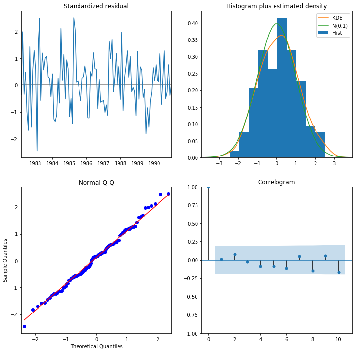

```python
# Summarize residual errors for the chosen ARIMA model
model = SARIMAX(time_series, order=final_ns_order, seasonal_order=final_ss_order)
results = model.fit()
print(results.summary())
results.plot_diagnostics(figsize=(12,12))
plt.show()
```

```python
if (notifyStatus): email_notify("Model Fitting and Evaluation completed! "+datetime.now().strftime('%a %B %d, %Y %I:%M:%S %p'))
```

## Section 5. Finalize Model

After models have been developed and a final model selected, it must be validated and finalized. Validation is an optional part of the process, but one that provides a ‘last check’ to ensure we have not fooled or lied to ourselves.

```python
if (notifyStatus): email_notify("Model Finalization has begun! "+datetime.now().strftime('%a %B %d, %Y %I:%M:%S %p'))
```

### 5.a) Validation via In-sample Data

```python
model = SARIMAX(time_series, order=final_ns_order, seasonal_order=final_ss_order)
results = model.fit()
forecast = results.get_prediction(start = -test_size)
mean_forecast = forecast.predicted_mean
confidence_intervals = forecast.conf_int()
```

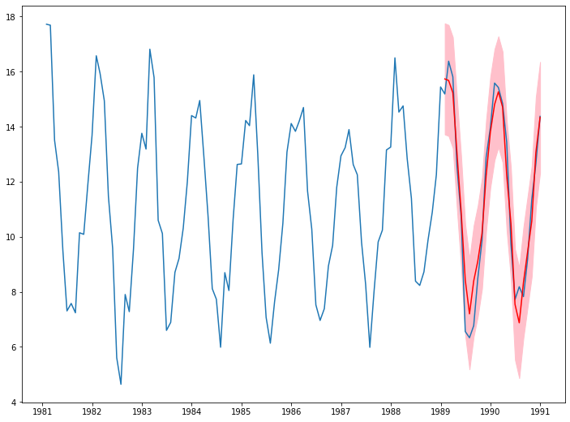

```python
plt.figure(figsize=(12,9))
plt.plot(time_series.index, time_series[target_col], label='observed')
plt.plot(mean_forecast.index, mean_forecast.values, color='red', label='forecast')
plt.fill_between(confidence_intervals.index, confidence_intervals[lower_bound], confidence_intervals[upper_bound], color='pink')
plt.show()
```

```python
# Evaluate RMSE for the validation data
y = time_series[-test_size:]
predictions = mean_forecast.values
rmse = math.sqrt(mean_squared_error(y, predictions))
print('RMSE from the validation data is: %.3f' % rmse)
```

```
RMSE from the validation data is: 0.782
```

### 5.b) Forecasting Out-of-Sample Data

```python
forecast = results.get_forecast(steps = test_size)
mean_forecast = forecast.predicted_mean
confidence_intervals = forecast.conf_int()
```

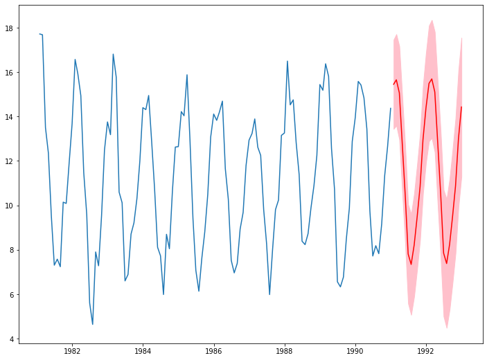

```python
plt.figure(figsize=(12,9))
plt.plot(time_series.index, time_series[target_col], label='observed')
plt.plot(mean_forecast.index, mean_forecast.values, color='red', label='forecast')
plt.fill_between(confidence_intervals.index, confidence_intervals[lower_bound], confidence_intervals[upper_bound], color='pink')
plt.show()
```

```python
if (notifyStatus): email_notify("Model Finalization completed! "+datetime.now().strftime('%a %B %d, %Y %I:%M:%S %p'))
```

```python
print ('Total time for the script:',(datetime.now() - startTimeScript))
```

```
Total time for the script: 0:01:49.069656
```